# Non-linear Regression

[Dr. Peng Zhao](https://connect.xjtlu.edu.cn/user/pengzhao) (✉ peng.zhao@xjtlu.edu.cn)

Department of Health and Environmental Sciences  
Xi’an Jiaotong-Liverpool University

# 1 Learning objectives

1. Understand what is non-linear regression
2. Understand how non-linear regression is performed
3. Evaluate non-linear regression models
4. Choose possible non-linear models

# 2 Principle

## 2.1 Definition

**Non-linear regression:**

A model for the relationship between the dependent variable(s) and the independent variable(s) is not linear but a curve

Two categories:

1. One that can be transformed into a linear model

2. One that cannot be transformed into a linear model

Examples:

1. $y = a + be^x$: Set $x' = e^x$, then $y = a + bx'$.
2. $y = a + b_1 x + b_2 x^2 +...+ b_m x^m$: Set $x_{i}=x^i,i=1,2,...,m$, then $y=a+b_{1}x_{1}+b_{2}x_{2}+...+b_{m}x_{m}$
3. $y=ae^{bx}$: Set $log(y)=log(a)+bx$ and $y'=log(y)$, then $y'=log(a)+bx$.
4. $z=a+be^{xy}$: cannot be transformed into linear.

| Name | Equation |
| --- | --- |
| Asymptotic functions |  |
| Michaelis-Menten | $y=\frac{a x}{b+cx}$ or $y=\frac{a x}{b+x}$ or… |
| 2-parameter asymptotic exponential | $y=a\left(1-\mathrm{e}^{-b x}\right)$ |
| 3-parameter asymptotic exponential | $y=a-b \mathrm{e}^{-c x}$ |
| S-shaped functions |  |
| 2-parameter logistic | $y=\frac{\mathrm{e}^{a+b x}}{1+\mathrm{e}^{a+b x}}$ |
| 3-parameter logistic | $y=\frac{a}{1+b \mathrm{e}^{-c x}}$ |
| 4-parameter logistic | $y=a+\frac{b-a}{1+\mathrm{e}^{(c-x) / d}}$ |
| Weibull | $y=a-b \mathrm{e}^{-\left(c x^d\right)}$ |
| Gompertz | $y=a \mathrm{e}^{-b \mathrm{e}^{-c x}}$ |
| Humped curves |  |
| Ricker curve | $y=a x \mathrm{e}^{-b x}$ |
| First-order compartment | $y=k \exp (-\exp (a) x)-\exp (-\exp (b) x)$ |
| Bell-shaped | $y=a \exp \left(-\|b x\|^2\right)$ |
| Biexponential | $y=a \mathrm{e}^{b x}-c \mathrm{e}^{-d x}$ |

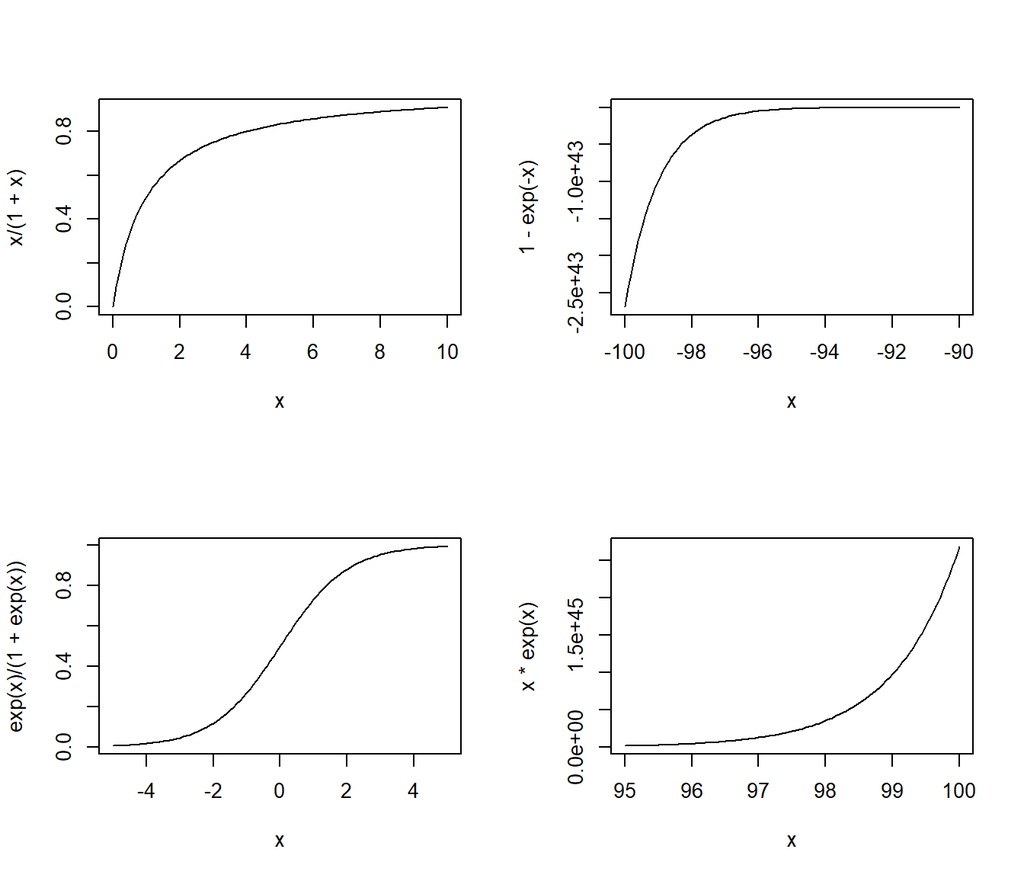

```r
par(mfrow = c(2,2))
curve(x/(1+x), 0, 10)
curve(1 - exp(-x), -100, -90)
curve(exp(x)/(1+exp(x)), -5, 5)
curve(x * exp(x), 95, 100)
```

## 2.2 Model

$$y_{i}=f(x_{i}, \theta)+\varepsilon_{i}, i=1,2,...,n$$

- $y_{i}$: The response variable.
- $x_{i}=(x_{i1},x_{i2},...,x_{ik})'$: The explanatory variable.
- $\theta=(\theta_{0},\theta_{1},...\theta_{p})'$: Unknown parameter vector.
- $\varepsilon_{i}$: Random error term.

Assumptions:

- $E(\varepsilon_{i})=0,i=1,2,...,n$: The mean value of random error term is 0
- $cor(\varepsilon_{i},\varepsilon_{j})=0,i,j=1,2,...,n$, where $i\neq j$: No correlation.
- $cov(\varepsilon_{i},\varepsilon_{j})=\sigma^2, i,j=1,2,...,n$, where $i=j$: Equal variance
- The explanatory variable is non-random variable
- $f(x_{i},\theta)$ is assumed to be a continuous differentiable function

## 2.3 Methods

Non-linear least squares (NLS):

$$Q(\theta)=\sum_{i=1}^{n}(y_{i}-f(x_{i},\theta))^2$$
For the minimal $Q(\theta)$:

$$\frac{\partial Q}{\partial \theta_{j}}=-2\sum_{i=1}^{n}(y_{i}-f(x_{i},\theta))\frac{\partial f}{\partial \theta_{j}}=0$$

Partial coefficient of determination: Measure the fitting of non-linear regression model.

$$R^2=1-\frac{SSE}{SST}$$

# 3 Workflow

## 3.1 Data

Reaction rate ~ concentration

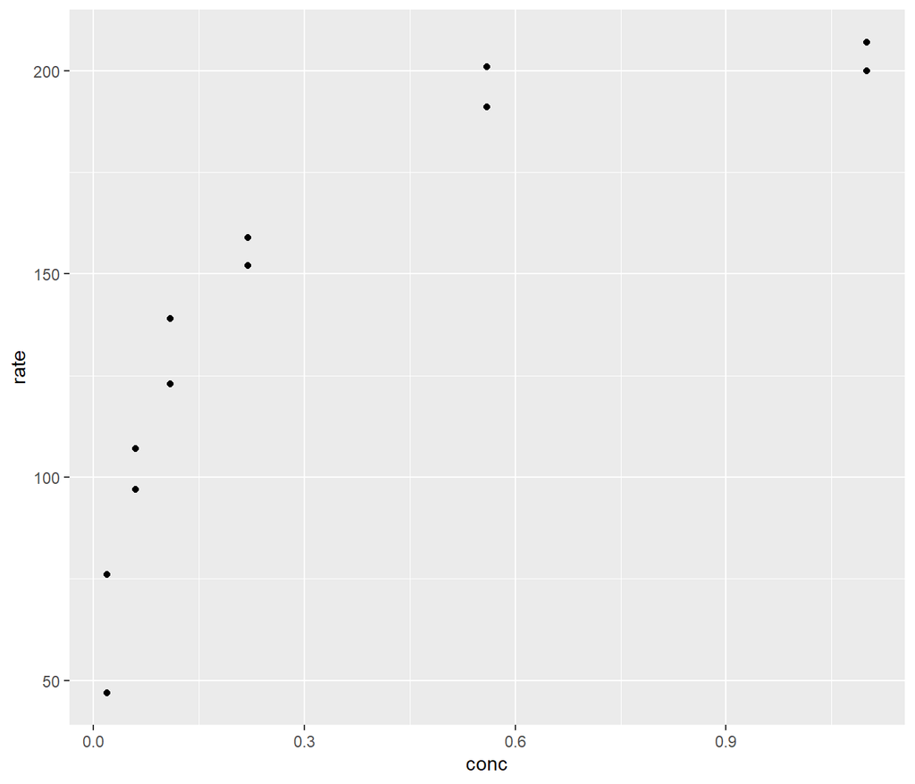

```r
dtf <- read.table("data/mm.txt", header = TRUE)
library(ggplot2)
ggplot(dtf) + geom_point(aes(conc, rate))
```

## 3.2 Fit the Model

Michaelis-Menten model $y=\frac{a x}{b+x}$:

- Biochemistry: the relationship between the reaction rate and the substrate concentration
- Ecology: (Holling’s disc equation) the relationship between the feeding rate of predator and the prey density.

Features:

1. The curve passes through the origin.
2. Rising rate of the curve diminishes with the increasing of x.
3. Function has an asymptote $y = a$.
4. $y = a/2$ when $x = b$.

```r
m1 <- nls(rate ~ a * conc / (b + conc), data = dtf, start = list(a = 200, b = 0.03))
m1
summary(m1)
```

[output not shown]

$$r = \frac{212.7c}{0.06412+c}$$

3-parameter asymptotic exponential model $y=a-b \mathrm{e}^{-c x}$:

```r
m2 <- nls(rate ~ a - b * exp(-c * conc), data = dtf, start = list(a = 200, b = 150, c = 5))
m2
summary(m2)
```

[output not shown]

$$r = 201 - 153 e^{-6.38c}$$

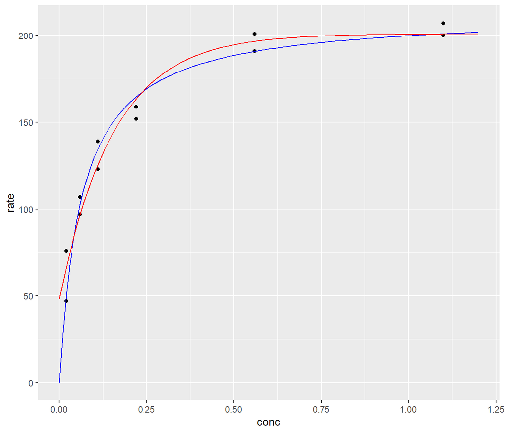

```r
xv <- seq(0, 1.2, .01)
y1 <- predict(m1, list(conc = xv))
y2 <- predict(m2, list(conc = xv))
dtf_predicted <- data.frame(xv, y1, y2)
ggplot(dtf) +
  geom_point(aes(conc, rate)) +
  geom_line(aes(xv, y1), data = dtf_predicted, color = 'blue') +
  geom_line(aes(xv, y2), data = dtf_predicted, color = 'red')
```

Partial coefficient of determination:

$$R^{2}=1-\frac{SSE}{SST}$$

```r
calc_R2 <- function(model) {
  ms <- summary(model)
  sse <- as.vector((ms[[3]])^2 * ms$df[2])
  null <- lm(dtf$rate ~ 1)
  sst <- as.vector(unlist(summary.aov(null)[[1]][2]))
  1 - sse/sst
}

calc_R2(m1)
```

```
[1] 0.9612608
```

```r
calc_R2(m2)
```

```
[1] 0.9672987
```

## 3.4 Automatic starting values

```r
m3 <- nls(rate ~ SSmicmen(conc, a, b), data = dtf)
summary(m3)

m4 <- nls(rate ~ SSasympOff(conc, a, b, c), data = dtf)
summary(m4)
```

[output not shown]

| Function | Model |
| --- | --- |
| `SSasymp()` | asymptotic regression model |
| `SSasympOff()` | asymptotic regression model with an offset |
| `SSasympOrig()` | asymptotic regression model through the origin |
| `SSbiexp()` | biexponential model |
| `SSfol()` | first-order compartment model |
| `SSfpl()` | four-parameter logistic model |
| `SSgompertz()` | Gompertz growth model |
| `SSlogis()` | logistic model |
| `SSmicmen()` | Michaelis–Menten model |
| `SSweibull()` | Weibull growth curve model |

# 4 Further readings

- [Nonlinear Regression with R. Christian Ritz & Jens Carl Streibig.](https://link.springer.com/book/10.1007/978-0-387-09616-2)
- [First steps with Non-Linear Regression in R. R bloggers.](https://www.r-bloggers.com/2016/02/first-steps-with-non-linear-regression-in-r/)